# Ship data analysis example

[figure not shown]

This tutorial uses AIS data published by the Danish Maritime Authority. The AIS record sample extracted for this tutorial covers vessel traffic on the 5th July 2017 near Gothenburg.

This tutorial covers:

1. Trajectory data preprocessing
   - Loading movement data from common geospatial file formats
   - Exploring spatial & non-spatial data distributions
   - Applying filters to extract relevant data
   - Converting GeoDataFrames into Trajectories describing continuous tracks of moving objects
2. Trajectory analysis
   - Visualizing trajectories and their properties
   - Filtering trajectories by area of interest
   - Splitting continuous tracks into individual trips
   - Exploring trip properties including: origins, destinations, and attributes

```python
import numpy as np
import pandas as pd
import geopandas as gpd
import movingpandas as mpd
import shapely as shp
import hvplot.pandas
import matplotlib.pyplot as plt

from geopandas import GeoDataFrame, read_file
from shapely.geometry import Point, LineString, Polygon
from datetime import datetime, timedelta
from holoviews import opts, dim
from os.path import exists
from urllib.request import urlretrieve

import warnings
warnings.filterwarnings('ignore')

plot_defaults = {'linewidth':5, 'capstyle':'round', 'figsize':(9,3), 'legend':True}
opts.defaults(opts.Overlay(active_tools=['wheel_zoom'], frame_width=500, frame_height=400))
hvplot_defaults = {'tiles':None, 'cmap':'Viridis', 'colorbar':True}

mpd.show_versions()
```

```
MovingPandas 0.18.1

SYSTEM INFO
-----------
python     : 3.10.14 | packaged by conda-forge | (main, Mar 20 2024, 12:40:08) [MSC v.1938 64 bit (AMD64)]
executable : c:\Users\Agarkovam\AppData\Local\miniforge3\envs\mpd-ex\python.exe
machine    : Windows-10-10.0.19045-SP0

GEOS, GDAL, PROJ INFO
---------------------
GEOS       : None
GEOS lib   : None
GDAL       : 3.8.5
GDAL data dir: None
PROJ       : 9.4.0
PROJ data dir: C:\Users\Agarkovam\AppData\Local\miniforge3\envs\mpd-ex\Library\share\proj

PYTHON DEPENDENCIES
-------------------
geopandas  : 0.14.4
pandas     : 2.2.2
fiona      : 1.9.6
numpy      : 1.26.4
shapely    : 2.0.4
rtree      : 1.2.0
pyproj     : 3.6.1
matplotlib : 3.8.4
mapclassify: 2.6.1
geopy      : 2.4.1
holoviews  : 1.17.1
hvplot     : 0.8.3
geoviews   : 1.9.6
stonesoup  : 1.2
```

## Loading sample AIS data

```python
%%time
df = read_file('../data/ais.gpkg')
print(f"Finished reading {len(df)}")
```

```
Finished reading 84702
CPU times: total: 12.7 s
Wall time: 12.9 s
```

Let's see what the data looks like:

```python
df.head()
```

|  | Timestamp | MMSI | NavStatus | SOG | COG | Name | ShipType | geometry |
| --- | --- | --- | --- | --- | --- | --- | --- | --- |
| 0 | 05/07/2017 00:00:03 | 219632000 | Under way using engine | 0.0 | 270.4 | None | Undefined | POINT (11.85958 57.68817) |
| 1 | 05/07/2017 00:00:05 | 265650970 | Under way using engine | 0.0 | 0.5 | None | Undefined | POINT (11.84175 57.66150) |
| 2 | 05/07/2017 00:00:06 | 265503900 | Under way using engine | 0.0 | 0.0 | None | Undefined | POINT (11.90650 57.69077) |
| 3 | 05/07/2017 00:00:14 | 219632000 | Under way using engine | 0.0 | 188.4 | None | Undefined | POINT (11.85958 57.68817) |
| 4 | 05/07/2017 00:00:19 | 265519650 | Under way using engine | 0.0 | 357.2 | None | Undefined | POINT (11.87192 57.68233) |

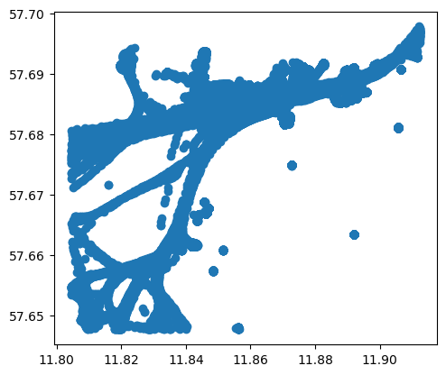

```python
df.plot()
```

If we look at the data distributions, we can see that there are a lot of records with speed over ground (SOG) values of zero in this dataframe:

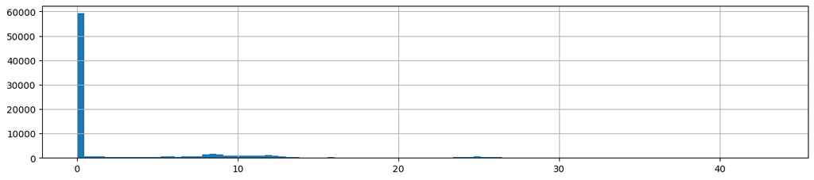

```python
df['SOG'].hist(bins=100, figsize=(15,3))
```

Let's get rid of these rows with zero SOG:

```
Original size: 84702 rows
Reduced to 33593 rows after removing 0 speed records
```

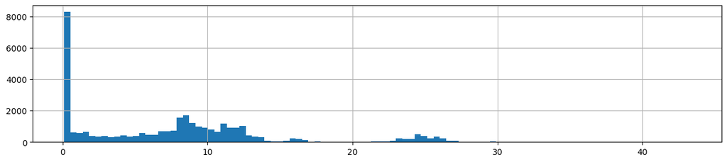

```python
print(f"Original size: {len(df)} rows")
df = df[df.SOG>0]
print(f"Reduced to {len(df)} rows after removing 0 speed records")
df['SOG'].hist(bins=100, figsize=(15,3))
```

Let's see what kind of ships we have in our dataset:

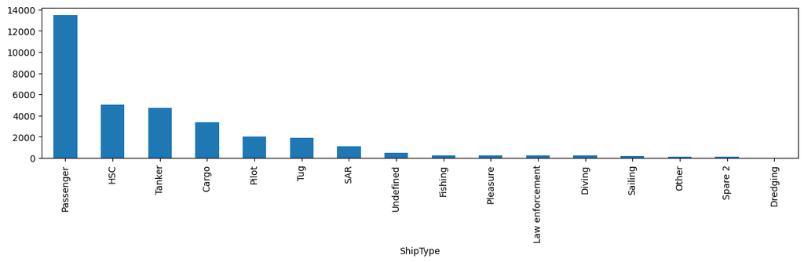

```python
df['ShipType'].value_counts().plot(kind='bar', figsize=(15,3))
```

Finally, let's create trajectories:

```python
%%time
df['t'] = pd.to_datetime(df['Timestamp'], format='%d/%m/%Y %H:%M:%S')
traj_collection = mpd.TrajectoryCollection(df, 'MMSI', t='t', min_length=100)
print(f"Finished creating {len(traj_collection)} trajectories")
```

```
Finished creating 77 trajectories
CPU times: total: 3.86 s
Wall time: 3.97 s
```

```python
traj_collection = mpd.MinTimeDeltaGeneralizer(traj_collection).generalize(tolerance=timedelta(minutes=1))
```

## Plotting trajectories

Let's give the most common ship types distinct colors. The remaining ones will be just grey:

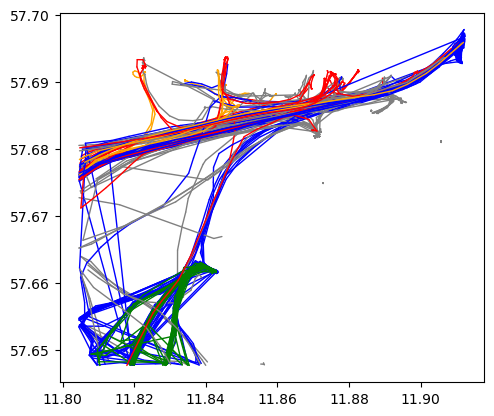

```python
shiptype_to_color = {'Passenger': 'blue', 'HSC': 'green', 'Tanker': 'red', 'Cargo': 'orange', 'Sailing': 'grey', 'Other': 'grey',
                     'Tug': 'grey', 'SAR': 'grey', 'Undefined': 'grey', 'Pleasure': 'grey', 'Dredging': 'grey', 'Law enforcement': 'grey',
                    'Pilot': 'grey', 'Fishing': 'grey', 'Diving':'grey', 'Spare 2': 'grey'}
traj_collection.plot(column='ShipType', column_to_color=shiptype_to_color, linewidth=1, capstyle='round')
```

```python
passenger = traj_collection.filter('ShipType', 'Passenger')
passenger.hvplot(title='Passenger ferries', line_width=2, frame_width=700, frame_height=500)
```

[interactive chart not shown]

## Visualizing trajectory properties

We can also plot individual trajectories to better visualize their properties, such as the changes in NavStatus:

```python
my_traj = traj_collection.trajectories[0]
my_traj.df.head()
```

| t | Timestamp | MMSI | NavStatus | SOG | COG | Name | ShipType | geometry |
| --- | --- | --- | --- | --- | --- | --- | --- | --- |
| 2017-07-05 17:32:18 | 05/07/2017 17:32:18 | 210035000 | Under way using engine | 9.8 | 52.8 | NORDIC HAMBURG | Cargo | POINT (11.80462 57.67612) |
| 2017-07-05 17:33:18 | 05/07/2017 17:33:18 | 210035000 | Under way using engine | 9.5 | 58.9 | NORDIC HAMBURG | Cargo | POINT (11.80875 57.67773) |
| 2017-07-05 17:34:18 | 05/07/2017 17:34:18 | 210035000 | Under way using engine | 9.3 | 70.5 | NORDIC HAMBURG | Cargo | POINT (11.81311 57.67879) |
| 2017-07-05 17:35:28 | 05/07/2017 17:35:28 | 210035000 | Under way using engine | 9.5 | 71.1 | NORDIC HAMBURG | Cargo | POINT (11.81855 57.67968) |
| 2017-07-05 17:36:28 | 05/07/2017 17:36:28 | 210035000 | Under way using engine | 9.4 | 71.3 | NORDIC HAMBURG | Cargo | POINT (11.82334 57.68044) |

```python
my_traj.df.tail()
```

| t | Timestamp | MMSI | NavStatus | SOG | COG | Name | ShipType | geometry |
| --- | --- | --- | --- | --- | --- | --- | --- | --- |
| 2017-07-05 22:47:34 | 05/07/2017 22:47:34 | 210035000 | Moored | 0.1 | 276.0 | NORDIC HAMBURG | Cargo | POINT (11.84571 57.68958) |
| 2017-07-05 23:08:44 | 05/07/2017 23:08:44 | 210035000 | Moored | 0.1 | 96.0 | NORDIC HAMBURG | Cargo | POINT (11.84571 57.68958) |
| 2017-07-05 23:09:54 | 05/07/2017 23:09:54 | 210035000 | Moored | 0.1 | 96.0 | NORDIC HAMBURG | Cargo | POINT (11.84571 57.68958) |
| 2017-07-05 23:11:45 | 05/07/2017 23:11:45 | 210035000 | Moored | 0.1 | 96.0 | NORDIC HAMBURG | Cargo | POINT (11.84571 57.68958) |
| 2017-07-05 23:35:58 | 05/07/2017 23:35:58 | 210035000 | Moored | 0.1 | 276.0 | NORDIC HAMBURG | Cargo | POINT (11.84571 57.68958) |

```python
my_traj.hvplot(title=f'Trajectory {my_traj.id}', frame_width=700, frame_height=500, line_width=5.0, c='NavStatus', cmap='Dark2')
```

[interactive chart not shown]

## Finding ships passing under Älvsborgsbron bridge

We can find ships passing under the bridge based on trajectory intersections with the bridge area.

```python
area_of_interest = Polygon([(11.89935, 57.69270), (11.90161, 57.68902), (11.90334, 57.68967), (11.90104, 57.69354), (11.89935, 57.69270)])
```

```python
intersecting = traj_collection.get_intersecting(area_of_interest)
print(f"Found {len(intersecting)} intersections")
```

```
Found 20 intersections
```

```python
bridge_traj = intersecting.trajectories[0]
bridge_traj.hvplot(title=f'Trajectory {bridge_traj.id}', frame_width=700, frame_height=500, line_width=5.0, c='NavStatus', cmap='Dark2')
```

[interactive chart not shown]

```python
bridge_traj.df.head()
```

| t | Timestamp | MMSI | NavStatus | SOG | COG | Name | ShipType | geometry |
| --- | --- | --- | --- | --- | --- | --- | --- | --- |
| 2017-07-05 01:21:57 | 05/07/2017 01:21:57 | 219011922 | Under way using engine | 8.8 | 227.7 | SCANDINAVIA | Tanker | POINT (11.91230 57.69633) |
| 2017-07-05 01:23:06 | 05/07/2017 01:23:06 | 219011922 | Under way using engine | 8.7 | 227.5 | SCANDINAVIA | Tanker | POINT (11.90842 57.69440) |
| 2017-07-05 01:24:06 | 05/07/2017 01:24:06 | 219011922 | Under way using engine | 8.7 | 227.0 | SCANDINAVIA | Tanker | POINT (11.90515 57.69275) |
| 2017-07-05 01:25:06 | 05/07/2017 01:25:06 | 219011922 | Under way using engine | 8.6 | 238.8 | SCANDINAVIA | Tanker | POINT (11.90161 57.69129) |
| 2017-07-05 01:26:08 | 05/07/2017 01:26:08 | 219011922 | Under way using engine | 8.5 | 245.4 | SCANDINAVIA | Tanker | POINT (11.89763 57.69015) |

## Identifying trip origins and destinations

Since AIS records with a speed over ground (SOG) value of zero have been removed from the dataset, we can use the `split_by_observation_gap()` function to split the continuous observations into individual trips:

```python
trips = mpd.ObservationGapSplitter(passenger).split(gap=timedelta(minutes=5))
print(f"Extracted {len(trips)} individual trips from {len(passenger)} continuous vessel tracks")
```

```
Extracted 90 individual trips from 14 continuous vessel tracks
```

Let's plot the resulting trips!

```python
trips.hvplot(title='Passenger ferry trips', line_width=2, frame_width=700, frame_height=500)
```

[interactive chart not shown]

Compared to plotting the original continuous observations, this visualization is much cleaner because there are no artifacts at the border of the area of interest.

Next, let's get the trip origins:

```python
origins = trips.get_start_locations()
origins.hvplot(title='Trip origins by ship type', c='Name', geo=True, tiles='OSM', frame_width=700, frame_height=500)
```

[interactive chart not shown]

In our data sample, trip origins can be:

- When a ship departs its anchoring location and the speed changes from 0 to >0
- When a ship trajectory first enters the observation area

```python
origins.hvplot(title='Origins by speed', c='SOG', geo=True, tiles='OSM', frame_width=700, frame_height=500)
```

[interactive chart not shown]

## Finding ships that depart from Sjöfartsverket (Maritime Administration)

```python
trips = mpd.ObservationGapSplitter(traj_collection).split(gap=timedelta(minutes=5))
area_of_interest = Polygon([(11.86815, 57.68273), (11.86992, 57.68047), (11.87419, 57.68140), (11.87288, 57.68348), (11.86815, 57.68273)])
```

We can identify vessels that start their trip within a given area of interest by intersecting trip starting locations with our area of interest:

```python
departures = [traj for traj in trips if traj.get_start_location().intersects(area_of_interest) and traj.get_length() > 100]
print(f"Found {len(departures)} departures")
```

```
Found 12 departures
```

```python
tc = mpd.TrajectoryCollection(departures)
tc.hvplot(title=f'Ships departing from Sjöfartsverket', line_width=3, frame_width=700, frame_height=500, hover_cols=['Name'])
```

[interactive chart not shown]

Let's see what kind of ships depart from here:

```python
for traj in departures:
    print(f"{traj.df['ShipType'].iloc[0]} vessel '{traj.df['Name'].iloc[0]}' departed at {traj.get_start_time()}")
```

```
Law enforcement vessel 'KBV 010' departed at 2017-07-05 10:36:03
Law enforcement vessel 'KBV 010' departed at 2017-07-05 14:33:02
Law enforcement vessel 'KBV 048' departed at 2017-07-05 10:20:44
Pilot vessel 'PILOT 794 SE' departed at 2017-07-05 01:21:07
Pilot vessel 'PILOT 794 SE' departed at 2017-07-05 04:15:04
Pilot vessel 'PILOT 794 SE' departed at 2017-07-05 06:58:56
Pilot vessel 'PILOT 794 SE' departed at 2017-07-05 08:45:08
Pilot vessel 'PILOT 794 SE' departed at 2017-07-05 12:02:18
Pilot vessel 'PILOT 794 SE' departed at 2017-07-05 13:34:42
Pilot vessel 'PILOT 794 SE' departed at 2017-07-05 22:32:47
Pilot vessel 'PILOT 218 SE' departed at 2017-07-05 09:27:24
Pilot vessel 'PILOT 218 SE' departed at 2017-07-05 16:10:29
```

Of course, the same works for arrivals:

```python
arrivals = [traj for traj in trips if traj.get_end_location().intersects(area_of_interest) and traj.get_length() > 100]
print(f"Found {len(arrivals)} arrivals")

for traj in arrivals:
    print(f"{traj.df['ShipType'].iloc[0]} vessel '{traj.df['Name'].iloc[0]}' arrived at {traj.get_end_time()}")
```

```
Found 12 arrivals
Law enforcement vessel 'KBV 010' arrived at 2017-07-05 10:51:03
Law enforcement vessel 'KBV 048' arrived at 2017-07-05 10:26:44
Pilot vessel 'PILOT 794 SE' arrived at 2017-07-05 01:36:56
Pilot vessel 'PILOT 794 SE' arrived at 2017-07-05 04:45:36
Pilot vessel 'PILOT 794 SE' arrived at 2017-07-05 08:16:46
Pilot vessel 'PILOT 794 SE' arrived at 2017-07-05 08:54:34
Pilot vessel 'PILOT 794 SE' arrived at 2017-07-05 13:06:37
Pilot vessel 'PILOT 794 SE' arrived at 2017-07-05 16:44:06
Pilot vessel 'PILOT 794 SE' arrived at 2017-07-05 23:58:49
Pilot vessel 'PILOT 218 SE' arrived at 2017-07-05 10:07:23
Pilot vessel 'PILOT 218 SE' arrived at 2017-07-05 17:46:12
Tanker vessel 'DANA' arrived at 2017-07-05 08:35:42
```

```python
tc = mpd.TrajectoryCollection(arrivals)
tc.hvplot(title=f'Ships arriving in Sjöfartsverket', line_width=3, frame_width=700, frame_height=500, hover_cols=['Name'])
```

[interactive chart not shown]

## Clustering origins

To run this section, you need to have the scikit-learn package installed.

```python
from sklearn.cluster import DBSCAN
from geopy.distance import great_circle
from shapely.geometry import MultiPoint
```

```python
origins = trips.get_start_locations()
origins['lat'] = origins.geometry.y
origins['lon'] = origins.geometry.x
matrix = origins[['lat','lon']].values
```

```python
kms_per_radian = 6371.0088
epsilon = 0.1 / kms_per_radian
```

```python
db = DBSCAN(eps=epsilon, min_samples=1, algorithm='ball_tree', metric='haversine').fit(np.radians(matrix))
cluster_labels = db.labels_
num_clusters = len(set(cluster_labels))
clusters = pd.Series([matrix[cluster_labels == n] for n in range(num_clusters)])
print(f'Number of clusters: {num_clusters}')
```

```
Number of clusters: 69
```

```python
origins['cluster'] = cluster_labels
```

```python
def get_centermost_point(cluster):
    centroid = (MultiPoint(cluster).centroid.x, MultiPoint(cluster).centroid.y)
    centermost_point = min(cluster, key=lambda point: great_circle(point, centroid).m)
    return Point(tuple(centermost_point)[1], tuple(centermost_point)[0])
centermost_points = clusters.map(get_centermost_point)
```

```python
origins.hvplot(title='Clustered origins', c='cluster', geo=True, tiles='OSM', cmap='glasbey_dark', frame_width=700, frame_height=500)
```

[interactive chart not shown]

```python
origins_by_cluster = pd.DataFrame(origins).groupby(['cluster'])
summary = origins_by_cluster['ShipType'].unique().to_frame(name='types')
summary['n'] = origins_by_cluster.size()
summary['sog'] = origins_by_cluster['SOG'].mean()
summary['geometry'] = centermost_points
summary = summary[summary['n']>1].sort_values(by='n', ascending=False)
summary.head()
```

| cluster | types | n | sog | geometry |
| --- | --- | --- | --- | --- |
| 5 | [Tanker, Passenger, Undefined, Fishing, Cargo] | 52 | 9.217308 | POINT (11.911787 57.69663) |
| 28 | [Passenger, Undefined, HSC] | 47 | 0.804255 | POINT (11.84232 57.661593) |
| 0 | [Cargo, Tanker, Tug, Passenger] | 28 | 11.946429 | POINT (11.80495 57.676108) |
| 27 | [Passenger, Undefined, HSC] | 24 | 15.9875 | POINT (11.819332 57.648027) |
| 11 | [SAR, Passenger] | 19 | 10.736842 | POINT (11.804653 57.654408) |

```python
cluster_of_interest_id = 28
origins[origins['cluster']==cluster_of_interest_id].hvplot(
    title=f'Cluster {cluster_of_interest_id}', c='ShipType', geo=True, tiles='OSM', frame_width=700, frame_height=500)
```

[interactive chart not shown]

```python
( trips.hvplot(title='Origin clusters by speed', color='gray', line_width=1, frame_width=700, frame_height=500) *
  GeoDataFrame(summary, crs=4326).hvplot(c='sog', size=np.sqrt(dim('n'))*3, geo=True,  cmap='RdYlGn')
)
```

[interactive chart not shown]

## Continue exploring MovingPandas

1. Bird migration analysis
2. Ship data analysis
3. Horse collar data exploration
4. OSM traces
5. Soccer game
6. Mars rover & heli
7. Ever Given
8. Iceberg